# 230417_liver_drug_edges

2023-04-17

# START

```
Goal/Purpose of operations:
I am going to be looking at the drug metabolism gene edges for the sex-specific networks across in the liver sex-specific networks.

Finished psedocode on:
230206

System which operations were done on:
my laptop

GitHub Repo:
230321_JLF_Sex_bias_adverse_events

Docker:
jenfisher7/rstudio_sex_bias_drugs

Directory of operations:
~/Documents/230321_JLF_Sex_bias_adverse_events

Scripts being edited for operations:
NA

Data being used:
results/alpaca/alpaca_runs

Papers and tools:
NA
```

# STEPS

### Set working directory

```r
source("~/src/sex_bias_drug_functions.R")
library(gprofiler2)
library(viridis)
```

```r
library(RColorBrewer)
library(ComplexHeatmap)
library(netZooR)
library(ggplot2)
library(GOSemSim)
library(parallel)
library(tidyverse)
library(circlize)
```

Start by looking at Liver by itself

```r
Liver_M_panda <- readRDS("~/results/alpaca/sex_specific_networks/Liver_M_panda.rds")
Liver_F_panda <- readRDS("~/results/alpaca/sex_specific_networks/Liver_F_panda.rds")
Liver__male_female_long <- readRDS("~/results/alpaca/alpaca_adjusted_inputs/Liver__topNet_regnet_male_female_long.rds")
```

```r
drug_genes <- c("ADH1A" ,"ADH1B", "ADH1C", "ADH4",  "ADH5", "ADH6", "ADH7",
                "ALDH1A3",  "ALDH3A1",  "ALDH3B1", "ALDH3B2", "AOX1", "CYP1A2",
                "CYP2A13", "CYP2A6", "CYP2A7",  "CYP2B6",   "CYP2C18",  "CYP2C19",
                "CYP2C8",   "CYP2C9",   "CYP2D6",   "CYP2E1",   "CYP3A4",   "CYP3A43",  "CYP3A5",
                "CYP3A7",   "FMO1", "FMO2", "FMO3", "FMO4", "FMO5",  "GSTA1", "GSTA2",  "GSTA3",    "GSTA4",
                "GSTA5",    "GSTK1",    "GSTM1",    "GSTM2",    "GSTM3",    "GSTM4",    "GSTM5",    "GSTO1",
                "GSTO2",    "GSTP1",    "GSTT1",    "GSTT2",    "GSTZ1",    "MAOA", "MAOB", "MGST1",
                "MGST2",    "MGST3",    "UGT1A1",   "UGT1A10",  "UGT1A3",   "UGT1A4",
                "UGT1A5",   "UGT1A6",   "UGT1A7",   "UGT1A8", "UGT1A9", "UGT2A1",   "UGT2A3", "UGT2B10",
                "UGT2B11",  "UGT2B15",  "UGT2B17",  "UGT2B28",  "UGT2B4",   "UGT2B7")
```

Now look at edges of drug metabolism genes in the liver

```r
Liver_tf_gene_sex_drug_only <- Liver__male_female_long[Liver__male_female_long$gene %in% drug_genes,]
```

```r
Liver_tf_gene_sex_drug_only <- Liver_tf_gene_sex_drug_only[ Liver_tf_gene_sex_drug_only$male == 1 | Liver_tf_gene_sex_drug_only$female == 1, ]
```

```r
all_male_tfs <- unique(Liver_tf_gene_sex_drug_only$TF[Liver_tf_gene_sex_drug_only$male == 1])
all_female_tfs <- unique(Liver_tf_gene_sex_drug_only$TF[Liver_tf_gene_sex_drug_only$female == 1])
```

```r
setdiff(all_male_tfs, all_female_tfs)
```

```
## [1] "ETS1"
```

```r
setdiff(all_female_tfs, all_male_tfs)
```

```
## character(0)
```

only one transcription factor is unique to male the rest are shared.

```r
Liver_sex_bias_tf_list <- readRDS("~/results/alpaca/panda_out_degree/Liver_sex_bias_tf_list.rds")
```

```r
all_tfs <- unique(all_female_tfs, all_male_tfs)
sex_div_tf <- Liver_sex_bias_tf_list[[1]][Liver_sex_bias_tf_list[[1]] %in% all_tfs]
length(sex_div_tf)
```

```
## [1] 400
```

```r
f_bias_tf <- Liver_sex_bias_tf_list[[2]][Liver_sex_bias_tf_list[[2]] %in% all_tfs]
length(f_bias_tf)
```

```
## [1] 0
```

```r
m_bias_tf <- Liver_sex_bias_tf_list[[3]][Liver_sex_bias_tf_list[[3]] %in% all_tfs]
length(m_bias_tf)
```

```
## [1] 0
```

```r
Liver_tf_gene_sex_drug_only[Liver_tf_gene_sex_drug_only$TF == "ETS1",]
```

```
##           TF    gene male female
## 4531733 ETS1 ALDH3B1    1      0
```

This gene encodes a member of the aldehyde dehydrogenase protein family. Aldehyde dehydrogenases are a family of isozymes that may play a major role in the detoxification of aldehydes generated by alcohol metabolism and lipid peroxidation. The encoded protein is able to oxidize long-chain fatty aldehydes in vitro, and may play a role in protection from oxidative stress.

To plot the edge relationships on a heatmap and have it cluster “1e-10”, “-1”, “0”, “1” == “no edge”, “male”, “both”, “female”

```r
Liver_tf_gene_sex_drug_only$edge_diff <- (Liver_tf_gene_sex_drug_only$female - Liver_tf_gene_sex_drug_only$male)
```

```r
liver_drug_edges <- pivot_wider(data= as.data.frame( Liver_tf_gene_sex_drug_only[,-c(3,4,6)] ), names_from = gene, values_from=edge_diff, values_fill= 1e-10)
```

```r
liver_drug_edges<- as.data.frame(liver_drug_edges)
rownames(liver_drug_edges)<- liver_drug_edges$TF
```

```r
liver_drug_edges<- liver_drug_edges[,-1]
```

```r
colors<- 1:4
names(colors)<- c("1e-10", "-1", "0", "1")
colors[1]<- "white"
colors[2]<- "#21908CFF"
colors[3]<- "lightgray"
colors[4]<- "#440154FF"

png("~/results/alpaca/drug_metabolism_genes/liver_drug_metabolism_edge_heatmap.png",width=15,height=10,units="in",res=1400)
Heatmap(liver_drug_edges, name = "Edge Present", col = colors, show_row_names = FALSE,
    column_title = "Male and female edges in liver networks",
    heatmap_legend_param = list(at = c("1e-10", "-1", "0", "1"),
                                labels= c("no edge", "male", "both", "female"),
                                column_names_gp =gpar(fontsize = 18 , fontface = "bold"),
                                labels_gp = gpar(fontsize = 12, fontface = "bold")))
dev.off()
```

annotating some of the tfs based on the number of sex-bias edges

```r
tf_count_table<- matrix(0, nrow= nrow(liver_drug_edges), ncol=4 )
for (i in 1:nrow(liver_drug_edges)){
  tf_count_sub <- table(unlist(liver_drug_edges[i,]))
  try(tf_count_table[i,1]<- tf_count_sub[names(tf_count_sub) == -1])
  try(tf_count_table[i,2]<- tf_count_sub[names(tf_count_sub) == 0])
  try(tf_count_table[i,3]<- tf_count_sub[names(tf_count_sub) == 1e-10 ])
  try(tf_count_table[i,4]<- tf_count_sub[names(tf_count_sub) == 1 ])
}
```

[output not shown]

[output cut: 873 more lines]

[output not shown]

```r
rownames(tf_count_table)<- rownames(liver_drug_edges)
```

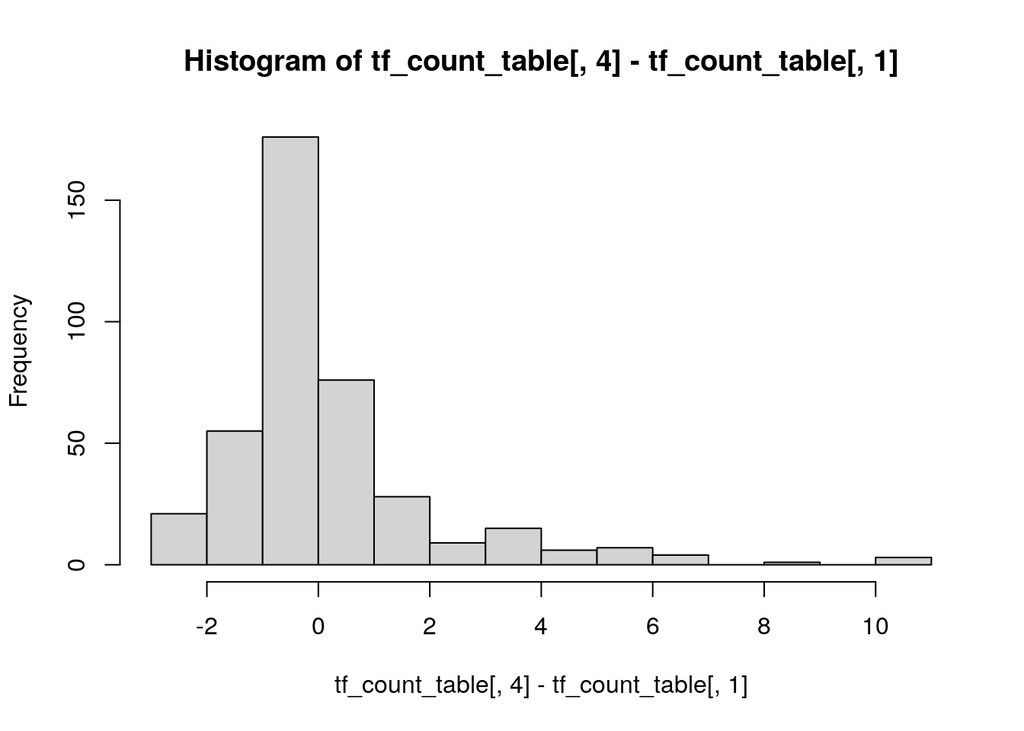

```r
hist(tf_count_table[,4] - tf_count_table[,1])
```

```r
print("male_tf_subset_drug_genes")
```

```
## [1] "male_tf_subset_drug_genes"
```

```r
rownames(tf_count_table)[(tf_count_table[,4]- tf_count_table[,1]) < -2]
```

```
## [1] "MEF2D"  "STAT5A" "PLAGL1"
```

```r
male_tf <- rownames(tf_count_table)[(tf_count_table[,4]- tf_count_table[,1]) < -2]
print("female_tf_subset_drug_genes")
```

```
## [1] "female_tf_subset_drug_genes"
```

```r
rownames(tf_count_table)[(tf_count_table[,4]- tf_count_table[,1]) > 4]
```

```
##  [1] "RELB"   "REL"    "TGIF1"  "RARB"   "SMAD3"  "NR2C1"  "RBPJ"   "ELF3"
##  [9] "ZEB1"   "NR5A2"  "PRDM1"  "RUNX2"  "RXRB"   "HIVEP1" "SNAI2"  "TCF4"
## [17] "RUNX3"  "NFYC"   "ATF5"   "VDR"    "ZNF282"
```

```r
female_tf <- rownames(tf_count_table)[(tf_count_table[,4]- tf_count_table[,1]) > 4]
```

```r
tf_sub  <- c(female_tf, male_tf )
tf_location <- (1:nrow(liver_drug_edges))[rownames(liver_drug_edges) %in% tf_sub]
Tf_anno <- anno_mark(at = tf_location, labels = rownames(liver_drug_edges)[tf_location], which = "row")
```

```r
png("~/results/alpaca/drug_metabolism_genes/liver_drug_metabolism_edge_heatmap_v2.png",width=15,height=10,units="in",res=1400)
Heatmap(liver_drug_edges, name = "Edge Present", col = colors, show_row_names = FALSE,
    column_title = "Male and female edges in liver networks",
    heatmap_legend_param = list(at = c("1e-10", "-1", "0", "1"),
                                labels= c("no edge", "male", "both", "female"),
                                column_names_gp =gpar(fontsize = 18 , fontface = "bold"),
                                labels_gp = gpar(fontsize = 12, fontface = "bold") )) +
  rowAnnotation(mark = Tf_anno)
dev.off()
```

For the liver sex-specific gene-regulatory networks, we determined the predicted regulation of the transcription factor and targeted gene by finding the Pearson correlation between a given transcription factor gene’s expression and the targeted drug gene metabolism gene’s expression. If the Pearson correlation was significant after Benjamini-Hochberg (BH) p-value adjustment and positive, we defined these edges as activator edges. If the Pearson correlation was significant after BH p-value adjustment and negative, we described these edges as repressor edges. If the correlation was not significant, we defined these relationships as undefined. We applied this in a sex-specific manner where we only correlated the transcription factor and target gene’s expression from one sex, and in a non-sex-specific manner as well.

```r
Liver_gtex_qsmooth_expression <- readRDS("~/results/lioness/processed_normalized_expression/Liver_gtex_processed_expression.rds")
Liver_gtex_metadata <- readRDS("~/data/gtex_qsmooth/Liver_gtex_metadata.rds")
```

```r
identical(colnames(Liver_gtex_qsmooth_expression), Liver_gtex_metadata$external_id)
```

```
## [1] TRUE
```

```r
Liver_gtex_qsmooth_expression<- as.data.frame(Liver_gtex_qsmooth_expression)
Liver_gtex_qsmooth_expression$genes <- rownames(Liver_gtex_qsmooth_expression)
Liver_gtex_qsmooth_expression_long <- pivot_longer(as.data.frame(Liver_gtex_qsmooth_expression), col=!genes, names_to = "sample", values_to = "expression")
```

```r
male_samples<- Liver_gtex_metadata$external_id[Liver_gtex_metadata$gtex.sex ==  "M"]
Liver_gtex_qsmooth_expression_long$sex <- Liver_gtex_qsmooth_expression_long$sample %in% male_samples
Liver_gtex_qsmooth_expression_long$sex <- ifelse(Liver_gtex_qsmooth_expression_long$sex, "male", "female")
```

```r
table(Liver_gtex_qsmooth_expression_long$sex)
```

```
##
##  female    male
## 1396950 3278176
```

Calculating correlation for all the TF and drug genes- estimate 30-40mins

```r
all_cor <- c()
all_p <- c()
f_cor <- c()
f_p <- c()
m_cor <- c()
m_p <- c()
for (i in 1:nrow(Liver_tf_gene_sex_drug_only)){
  tf_name <- Liver_tf_gene_sex_drug_only[i, 1]
  gene_name <- Liver_tf_gene_sex_drug_only[i, 2]
  #get tf expression
  tf <- Liver_gtex_qsmooth_expression_long$expression[Liver_gtex_qsmooth_expression_long$genes == tf_name]
  gene <-  Liver_gtex_qsmooth_expression_long$expression[Liver_gtex_qsmooth_expression_long$genes == gene_name]
  res <- cor.test(tf, gene, method = "pearson", exact = FALSE)
  all_cor[i] <- res$estimate
  all_p[i] <- res$p.value

  tf <- Liver_gtex_qsmooth_expression_long$expression[Liver_gtex_qsmooth_expression_long$genes == tf_name & Liver_gtex_qsmooth_expression_long$sex == "female"]
  gene <-  Liver_gtex_qsmooth_expression_long$expression[Liver_gtex_qsmooth_expression_long$genes == gene_name & Liver_gtex_qsmooth_expression_long$sex == "female"]
  res <- cor.test(tf, gene, method= "pearson",exact=FALSE)
  f_cor[i] <- res$estimate
  f_p[i] <- res$p.value

   tf <- Liver_gtex_qsmooth_expression_long$expression[Liver_gtex_qsmooth_expression_long$genes == tf_name & Liver_gtex_qsmooth_expression_long$sex == "male"]
  gene <-  Liver_gtex_qsmooth_expression_long$expression[Liver_gtex_qsmooth_expression_long$genes == gene_name & Liver_gtex_qsmooth_expression_long$sex == "male"]
  res <- cor.test(tf, gene, method = "pearson", exact = FALSE)
  m_cor[i] <- res$estimate
  m_p[i] <- res$p.value
}
Liver_tf_gene_sex_drug_only<- cbind(Liver_tf_gene_sex_drug_only, all_cor,all_p, m_cor, m_p, f_cor, f_p)
```

note the type of relationships between TF and gene

```r
Liver_tf_gene_sex_drug_only$all_rel <- ifelse(Liver_tf_gene_sex_drug_only$all_cor > 0, "pos", "neg")
Liver_tf_gene_sex_drug_only$f_rel <- ifelse(Liver_tf_gene_sex_drug_only$f_cor > 0, "pos", "neg")
Liver_tf_gene_sex_drug_only$m_rel <- ifelse(Liver_tf_gene_sex_drug_only$m_cor > 0, "pos", "neg")
```

pvalue correction (BH)

```r
Liver_tf_gene_sex_drug_only$all_p_adj <- p.adjust(Liver_tf_gene_sex_drug_only$all_p, method= "BH")
Liver_tf_gene_sex_drug_only$f_p_adj <- p.adjust(Liver_tf_gene_sex_drug_only$f_p, method= "BH")
Liver_tf_gene_sex_drug_only$m_p_adj <- p.adjust(Liver_tf_gene_sex_drug_only$m_p, method= "BH")
```

determine it was significant

```r
Liver_tf_gene_sex_drug_only$all_p_adj_tf <- ifelse( Liver_tf_gene_sex_drug_only$all_p_adj < 0.05, "yes", "no")
Liver_tf_gene_sex_drug_only$f_p_adj_tf <- ifelse( Liver_tf_gene_sex_drug_only$f_p_adj < 0.05, "yes", "no")
Liver_tf_gene_sex_drug_only$m_p_adj_tf <- ifelse( Liver_tf_gene_sex_drug_only$m_p_adj < 0.05, "yes", "no")
```

```r
Liver_tf_gene_sex_drug_only$summary <- paste(Liver_tf_gene_sex_drug_only$f_rel, Liver_tf_gene_sex_drug_only$f_p_adj_tf, Liver_tf_gene_sex_drug_only$m_rel, Liver_tf_gene_sex_drug_only$m_p_adj_tf, sep = "_")
```

```r
saveRDS(Liver_tf_gene_sex_drug_only, "~/results/alpaca/drug_metabolism_genes/liver_drug_metabolism_gene_edges.rds")
```

```r
Liver_tf_gene_sex_drug_both <- Liver_tf_gene_sex_drug_only[Liver_tf_gene_sex_drug_only$edge_diff == 0, ]

df_edge_cor_counts<- as.data.frame(table(Liver_tf_gene_sex_drug_both$summary))
```

```r
df_edge_cor_counts
```

```
##               Var1 Freq
## 1    neg_no_neg_no  471
## 2   neg_no_neg_yes  527
## 3    neg_no_pos_no  240
## 4   neg_no_pos_yes   51
## 5   neg_yes_neg_no   55
## 6  neg_yes_neg_yes  638
## 7   neg_yes_pos_no    6
## 8    pos_no_neg_no  292
## 9   pos_no_neg_yes   71
## 10   pos_no_pos_no  465
## 11  pos_no_pos_yes  426
## 12  pos_yes_neg_no   11
## 13 pos_yes_neg_yes    1
## 14  pos_yes_pos_no   63
## 15 pos_yes_pos_yes  709
```

```r
Liver_tf_gene_sex_drug_only$edge <- paste(Liver_tf_gene_sex_drug_only$TF, Liver_tf_gene_sex_drug_only$gene, sep= "_")
```

tfs activating in females

```r
f_act_edge <- unique(Liver_tf_gene_sex_drug_only$edge[Liver_tf_gene_sex_drug_only$f_cor > 0 & Liver_tf_gene_sex_drug_only$f_p_adj < 0.05 & Liver_tf_gene_sex_drug_only$female == 1 ])
```

tfs repressing in females

```r
f_repress_edge <-unique(Liver_tf_gene_sex_drug_only$edge[Liver_tf_gene_sex_drug_only$f_cor < 0 & Liver_tf_gene_sex_drug_only$f_p_adj < 0.05 & Liver_tf_gene_sex_drug_only$female == 1])
```

tfs activating in males

```r
m_act_edge <- unique(Liver_tf_gene_sex_drug_only$edge[Liver_tf_gene_sex_drug_only$m_cor > 0 & Liver_tf_gene_sex_drug_only$m_p_adj < 0.05  & Liver_tf_gene_sex_drug_only$male== 1])
```

```r
m_repress_edge <- unique(Liver_tf_gene_sex_drug_only$edge[Liver_tf_gene_sex_drug_only$m_cor < 0 & Liver_tf_gene_sex_drug_only$m_p_adj < 0.05  & Liver_tf_gene_sex_drug_only$male== 1])
```

make upset plot

```r
comb_mat<- make_comb_mat(list("Female Activator Edges"=f_act_edge, "Female Repressor Edges"=f_repress_edge, "Male Activator Edges"=m_act_edge, "Male Repressor Edges"=m_repress_edge), mode = "distinct")
```

```r
png("~/results/alpaca/drug_metabolism_genes/liver_drug_metabolism_edge_upset_plot.png",width=15,height=5,units="in",res=1200, type="cairo")
cs <-  comb_size(comb_mat)

plot<- UpSet(comb_mat, comb_order = order(-comb_size(comb_mat)), top_annotation = HeatmapAnnotation(
        "Intersection size" = anno_barplot(cs,
            ylim = c(0, max(cs)*1.1),
            border = FALSE,
            gp = gpar(fill = "black", fontsize = 11, face="bold"),
            height = unit(4, "cm")),
        annotation_name_side = "left",
        annotation_name_rot = 90))

plot_draw <- draw(plot)
od <- column_order(plot_draw)

decorate_annotation("Intersection size", {
    grid.text(cs[od], x = seq_along(cs), y = unit(cs[od], "native") + unit(2, "pt"),
        default.units = "native", just = c("left", "bottom"),
        gp = gpar(fontsize = 11, face="bold",col = "#404040"), rot = 45)})

dev.off()
```

pathway analysis on the different edges

```r
only_male_act_edges <- setdiff(m_act_edge, c(m_repress_edge, f_repress_edge, f_act_edge))
```

```r
only_male_act_tf_genes <- unique(unlist(str_split(only_male_act_edges, "_")))
```

```r
set.seed(101)
  pathway_results_male_act <- gost(query = only_male_act_tf_genes ,
                               organism = "hsapiens", ordered_query = FALSE,
                               multi_query = FALSE, significant = TRUE, exclude_iea= FALSE,
                               measure_underrepresentation = FALSE, evcodes = FALSE,
                               user_threshold = 0.05, correction_method = "g_SCS",
                               domain_scope = "annotated", custom_bg = NULL,
                               numeric_ns = "", as_short_link = FALSE)
   pathway_results_male_res_act <-  pathway_results_male_act$result
```

```r
only_male_repress_edges <- setdiff(m_repress_edge, c(f_repress_edge, f_act_edge ,m_act_edge))
```

```r
only_male_repress_tf_genes <- unique(unlist(str_split(only_male_repress_edges, "_")))
```

```r
set.seed(101)
  pathway_results_male_repress <- gost(query = only_male_repress_tf_genes ,
                               organism = "hsapiens", ordered_query = FALSE,
                               multi_query = FALSE, significant = TRUE, exclude_iea= FALSE,
                               measure_underrepresentation = FALSE, evcodes = FALSE,
                               user_threshold = 0.05, correction_method = "g_SCS",
                               domain_scope = "annotated", custom_bg = NULL,
                               numeric_ns = "", as_short_link = FALSE)
   pathway_results_male_res_repress <-  pathway_results_male_repress$result
```

```r
only_female_act_edges <- setdiff(f_act_edge, c(f_repress_edge, m_repress_edge, m_act_edge))
```

```r
only_female_act_tf_genes <- unique(unlist(str_split(only_female_act_edges, "_")))
```

```r
set.seed(101)
  pathway_results_female_act <- gost(query = only_female_act_tf_genes ,
                               organism = "hsapiens", ordered_query = FALSE,
                               multi_query = FALSE, significant = TRUE, exclude_iea= FALSE,
                               measure_underrepresentation = FALSE, evcodes = FALSE,
                               user_threshold = 0.05, correction_method = "g_SCS",
                               domain_scope = "annotated", custom_bg = NULL,
                               numeric_ns = "", as_short_link = FALSE)
   pathway_results_female_res_act <-  pathway_results_female_act$result
```

```r
only_female_repress_edges <- setdiff(f_repress_edge, c(m_repress_edge, m_act_edge ,f_act_edge))
```

```r
only_female_repress_tf_genes <- unique(unlist(str_split(only_female_repress_edges, "_")))
```

```r
set.seed(101)
  pathway_results_female_repress <- gost(query = only_female_repress_tf_genes ,
                               organism = "hsapiens", ordered_query = FALSE,
                               multi_query = FALSE, significant = TRUE, exclude_iea= FALSE,
                               measure_underrepresentation = FALSE, evcodes = FALSE,
                               user_threshold = 0.05, correction_method = "g_SCS",
                               domain_scope = "annotated", custom_bg = NULL,
                               numeric_ns = "", as_short_link = FALSE)
   pathway_results_female_res_repress <-  pathway_results_female_repress$result
```

Go semantic similarity analysis

```r
hsGO <- godata('org.Hs.eg.db', ont="BP")
```

```
## preparing gene to GO mapping data...
```

```
## preparing IC data...
```

```r
png("~/results/alpaca/drug_metabolism_genes/liver_drug_metabolism_edge_go_term_heatmap.png",width=15,height=10,units="in",res=1200, type="cairo")
go_term_heatmap_v2(pathway_results_female_res_act, pathway_results_female_res_repress, pathway_results_male_res_act , pathway_results_male_res_repress, threshold = 0.94, "~/results/alpaca/drug_metabolism_genes/liver_edge_differences_pathways.csv")
```

```
## No scores provided. Falling back to term's size
```

```r
dev.off()
```

Look at the targeting difference of activator vs repressor edges in male and female genes

```r
f_act_edge_df <- str_split(f_act_edge, "_", simplify = TRUE)
f_repress_edge_df <- str_split(f_repress_edge, "_", simplify = TRUE)

female_genes <- unique(c(f_act_edge_df[,2], f_repress_edge_df[,2]))
Liver_reg <- Liver_F_panda@regNet
diff_female <- c()

for (i in 1:length(female_genes)){

  f_act_tf_gene_sub <- f_act_edge_df[f_act_edge_df[,2] == female_genes[i] , 1]
  act_subnetwork <- Liver_reg[rownames(Liver_reg) %in% f_act_tf_gene_sub , colnames(Liver_reg) == female_genes[i]]

  f_repress_tf_gene_sub <- f_repress_edge_df[f_repress_edge_df[,2] == female_genes[i] , 1]
  repress_subnetwork <- Liver_reg[rownames(Liver_reg) %in% f_repress_tf_gene_sub , colnames(Liver_reg) == female_genes[i]]

  diff_female[i] <- sum(act_subnetwork)- sum(repress_subnetwork )
}

diff_female <- cbind( female_genes, diff_female)
colnames(diff_female) <- c("genes", "diff_female")
```

```r
m_act_edge_df <- str_split(m_act_edge, "_", simplify = TRUE)
m_repress_edge_df <- str_split(m_repress_edge, "_", simplify = TRUE)

male_genes <- unique(c(m_act_edge_df[,2], m_repress_edge_df[,2]))
Liver_reg <- Liver_M_panda@regNet
diff_male <- c()

for (i in 1:length(male_genes)){

  m_act_tf_gene_sub <- m_act_edge_df[m_act_edge_df[,2] == male_genes[i] , 1]
  act_subnetwork <- Liver_reg[rownames(Liver_reg) %in% m_act_tf_gene_sub , colnames(Liver_reg) == male_genes[i]]

  m_repress_tf_gene_sub <- m_repress_edge_df[m_repress_edge_df[,2] == male_genes[i] , 1]
  repress_subnetwork <- Liver_reg[rownames(Liver_reg) %in% m_repress_tf_gene_sub , colnames(Liver_reg) == male_genes[i]]

  diff_male[i] <- sum(act_subnetwork)- sum(repress_subnetwork )

}

diff_male <- cbind( male_genes, diff_male)
colnames(diff_male)<- c("genes", "diff_male")
```

```r
diff_both <- merge(diff_male, diff_female, by= "genes", all =TRUE)
```

```r
diff_both <- diff_both[complete.cases(diff_both),]
```

```r
diff_both$diff_male <- as.numeric(diff_both$diff_male)
diff_both$diff_female <- as.numeric(diff_both$diff_female)
```

```r
rownames(diff_both) <- diff_both[, 1]
diff_both <- diff_both[, -1]
```

```r
colnames(diff_both) <- c("Male", "Female")
```

```r
saveRDS(diff_both, "~/results/alpaca/drug_metabolism_genes/targeting_difference_act_vs_repress_both_sexes.rds" )
```

```r
#how many female act targetting
table(diff_both$Female > 0)
```

```
##
## FALSE  TRUE
##    33    30
```

```r
table(diff_both$Female < 0)
```

```
##
## FALSE  TRUE
##    30    33
```

```r
#how many male act targetting
table(diff_both$Male > 0)
```

```
##
## FALSE  TRUE
##    39    24
```

```r
table(diff_both$Male < 0)
```

```
##
## FALSE  TRUE
##    24    39
```

```r
diff_both[sign(diff_both$Male) != sign(diff_both$Female), ]
```

```
##                Male     Female
## ADH1A     2.6301804 -8.1960380
## ADH1B     2.6912695 -1.9829921
## ADH4    -18.5430721  1.1163564
## CYP1A2   13.8863218 -8.3459962
## CYP2C19 -18.7849066 16.3248647
## CYP2D6   -2.9468300  5.0640354
## FMO3     -5.3929063  4.1757714
## FMO5     -5.3072511  3.1988947
## GSTA1    -1.0646538  4.2792938
## GSTK1    -2.0035919  7.9658483
## GSTM1     0.2721085 -1.3059609
## GSTZ1    -5.8028551  0.6757579
## UGT1A8    5.1039784 -9.2619409
## UGT2B10  -0.3899725  0.8581456
## UGT2B11 -22.0227900  2.3975884
## UGT2B7  -24.2716117 35.2106914
```

```r
res <- wilcox.test(diff_both$Female, diff_both$Male, paired = TRUE)
```

```r
print(res)
```

```
##
##  Wilcoxon signed rank test with continuity correction
##
## data:  diff_both$Female and diff_both$Male
## V = 1504, p-value = 0.0006932
## alternative hypothesis: true location shift is not equal to 0
```

```r
png("~/results/alpaca/drug_metabolism_genes/liver_drug_metabolism_edge_act_repress_heatmap.png",width=12,height=20,units="in",res=1200, type="cairo")
Heatmap(diff_both, nam= "Activator - Repressor\nEdges",col = colorRamp2(c(-75, 0,  75), c( "blue", "black", "yellow")),
          show_column_names = TRUE,  show_row_names = TRUE,
          clustering_distance_rows = "euclidean",
          clustering_distance_columns =  "euclidean",
          clustering_method_rows = "ward.D2" , column_names_rot = 45,
          row_names_gp = gpar(fontface = "bold", fontsize = 18 ),
          column_names_gp =gpar(fontsize = 18 , fontface = "bold"),
          clustering_method_columns="ward.D2",
        heatmap_legend_param = list( title_gp = gpar(fontsize = 20 , fontface = "bold", at = c(-75,0,75)),
                                     labels_gp = gpar(fontsize = 12, fontface = "bold")))
dev.off()
```

# END

```
Location of final scripts:
src
Location of data produced:
~/results/alpaca/drug_metabolism_genes
Dates when operations were done:
230418
```